# Spotify Visualization

Author

Lina Rowbotham

# Let’s talk about Billy Joel

## Who is Billy Joel?

Billy Joel (b. 1949) is an American singer and pianist. He is one of the best-selling singers in history, having released pop, rock and classical music. Over his 50+ year, Billy Joel has won five Grammys, has received Kennedy Center Honors (the highest honor for contribution to American arts) and has received the Gershwin Prize for Popular Song. He is widely considered one of the most influential American singers of all time.

## His quote:

> *“Musicians want to be the loud voice for so many quiet hearts.”*

> - Billy Joel (1993 Berklee College of Music Commencement Speech)

## His albums:

- Cold Spring Harbor (1971)
- Piano Man (1973)
- Streetlife Serenade (1974)
- Turnstiles (1976)
- The Stranger (1977)
- 52nd Street (1978)
- Glass Houses (1980)
- The Nylon Curtain (1982)
- An Innocent Man (1983)
- The Bridge (1986)
- Storm Front (1989)
- River of Dreams (1993)
- Fantasies and Delusions (2001)

## My Picks:

### Favorite Album:

[figure not shown]

### Favorite Song:

[Uptown Girl (1983, Youtube Link)](https://www.youtube.com/watch?v=hCuMWrfXG4E)

[video not shown]

### Favorite Lyrics:

> *“We are forced to recognize our inhumanity*

> *Our reason co-exists with our insanity*

> *And though we choose between reality and madness, it’s either sadness or euphoria.”*

> - Billy Joel, “Summer, Highland Falls” (Turnstiles, 1976)

## Data Analysis:

### Import Data:

```r
library(dplyr)
library(readr)
library(ggplot2)

df <- read.csv("singers_2023/Billy_Joel.csv")
```

### Data Frame:

```r
df |> dplyr::slice_sample(n=5) |> knitr::kable(digits=2)
```

| artist_name | track_name | track_number | album_name | album_release_year | energy | valence | danceability | loudness | speechiness | liveness | tempo | key_mode | duration_ms |
| --- | --- | --- | --- | --- | --- | --- | --- | --- | --- | --- | --- | --- | --- |
| Billy Joel | Pressure | 3 | The Nylon Curtain | 1982 | 0.68 | 0.85 | 0.55 | -8.68 | 0.05 | 0.09 | 148.49 | A minor | 280333 |
| Billy Joel | She’s Right On Time | 5 | The Nylon Curtain | 1982 | 0.86 | 0.29 | 0.37 | -8.46 | 0.06 | 0.06 | 151.71 | A major | 252533 |
| Billy Joel | Odoya | 1 | A Matter of Trust - The Bridge to Russia: The Music (Live) | 2014 | 0.34 | 0.17 | 0.35 | -14.09 | 0.04 | 0.06 | 117.00 | A# minor | 76040 |
| Billy Joel | Storm Front | 6 | Storm Front | 1989 | 0.78 | 0.90 | 0.70 | -4.31 | 0.03 | 0.05 | 99.43 | F major | 316866 |
| Billy Joel | Piano Man | 2 | Piano Man | 1973 | 0.48 | 0.41 | 0.33 | -8.81 | 0.03 | 0.31 | 179.24 | C major | 336200 |

### Data Preparation:

I’ve removed tracks that were duplicated to clean the data. I have also removed live versions of tracks and removed the classical albums to keep the dataset consistent.

```r
#removing duplicates
df = df |> distinct(track_name, .keep_all = TRUE)
#removing live and piano songs
df = df |> filter(!grepl("Live|Opus", album_name))
#numeric to character
df$album_name = as.character(df$album_name)
```

### Album Analysis (Valence and Energy):

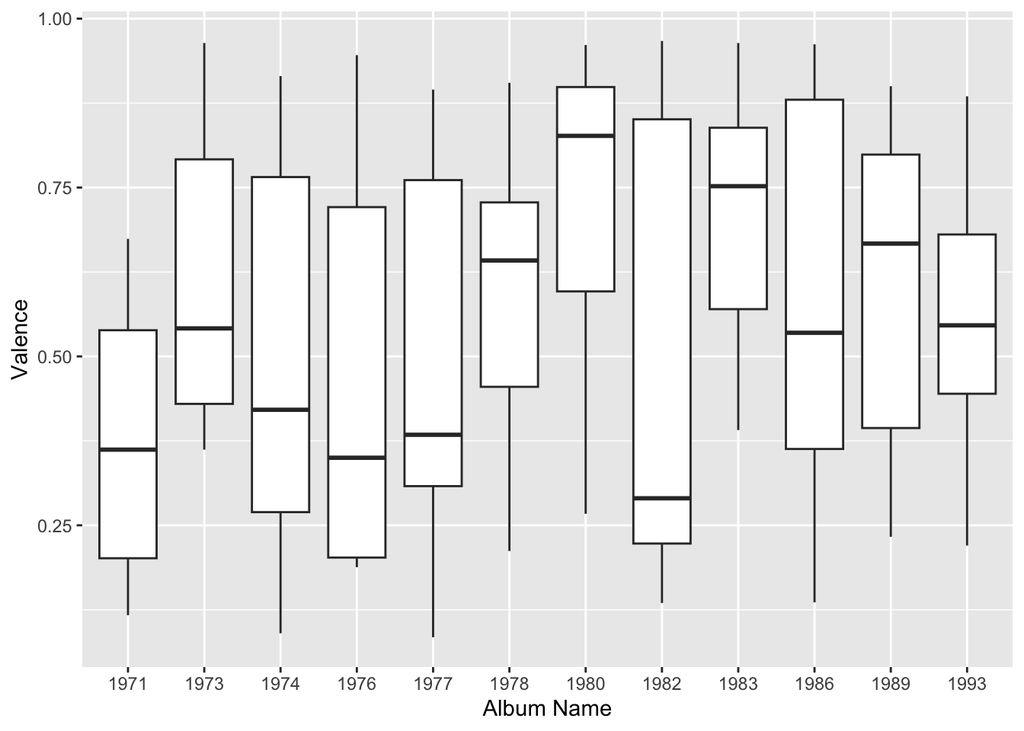

```r
#boxplot
ggplot(df, aes(x=as.factor(album_release_year), y=valence)) +
  geom_boxplot() +
  labs(x="Album Name", y="Valence")
```

We can see that Billy Joel’s albums there is no clear trend in terms of valence. We can notice that the album released in 1982 (The Nylon Curtain) has a very low median and does not follow the generally high valence trend of Billy’s Joel’s later career years. It turns out Billy Joel got divorced in 1982, which explains the very sad album!

Maybe the spread of energy will tell us more?

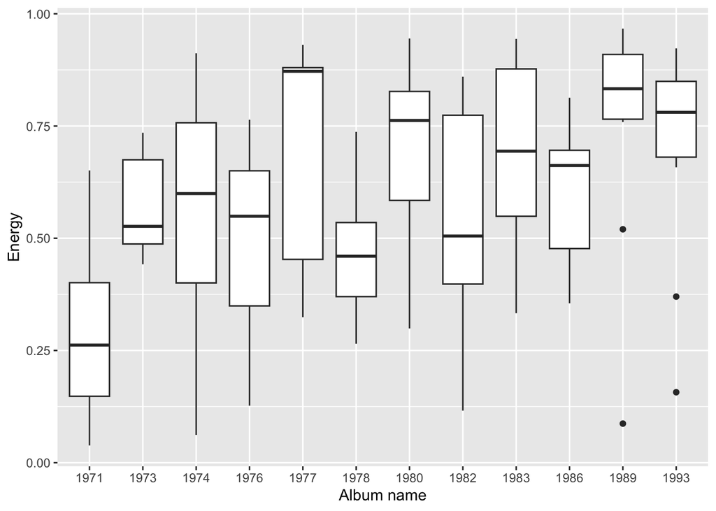

```r
ggplot(df, aes(x=as.factor(album_release_year), y=energy))+
  geom_boxplot()+
  labs(x="Album name", y="Energy")
```

We can see that Billy Joel’s albums have tended to get more energetic as time has passed. Billy Joel’s first album (Cold Spring Harbor, 1971) is particularly notable for its low energy. This may be because there were technical problems in the mastering of the album, causing the album to be a critical and commercial failure. Maybe Billy Joel learned from this and made his albums more energetic to gain more success?

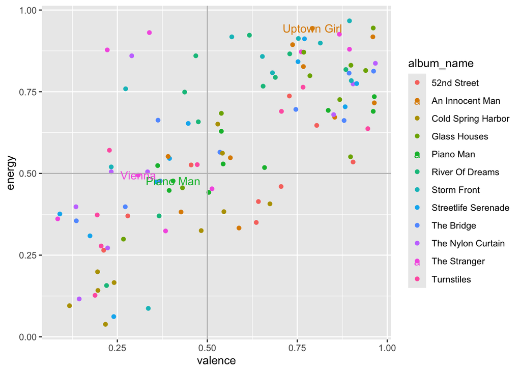

```r
subgroup <-df|> filter(track_name%in% c("Piano Man", "Uptown Girl", "Vienna"))

ggplot(df, aes(x = valence, y = energy, color = album_name))+
  geom_point()+
  geom_hline(yintercept= 0.5, color="grey")+
  geom_vline(xintercept= 0.5, color="grey")+
  geom_text(data=subgroup, aes(label=track_name))
```

### 3 Most Positive Songs:

```r
df |> slice_max(valence, n=3) |> dplyr::select(track_name, album_name, album_release_year, valence) |> knitr::kable(digits = 2)
```

| track_name | album_name | album_release_year | valence |
| --- | --- | --- | --- |
| Allentown | The Nylon Curtain | 1982 | 0.97 |
| Ain’t No Crime | Piano Man | 1973 | 0.96 |
| Careless Talk | An Innocent Man | 1983 | 0.96 |

### 3 Most Negative Songs:

```r
df |> slice_min(valence, n=3) |> dplyr::select(track_name, album_name, album_release_year, valence) |> knitr::kable(digits = 2)
```

| track_name | album_name | album_release_year | valence |
| --- | --- | --- | --- |
| Everybody Has a Dream | The Stranger | 1977 | 0.08 |
| Streetlife Serenader | Streetlife Serenade | 1974 | 0.09 |
| Got to Begin Again | Cold Spring Harbor | 1971 | 0.12 |

### 3 Most Energetic Songs:

```r
df |> slice_max(energy, n=3) |> dplyr::select(track_name, album_name, album_release_year, energy) |> knitr::kable(digits = 2)
```

| track_name | album_name | album_release_year | energy |
| --- | --- | --- | --- |
| We Didn’t Start the Fire | Storm Front | 1989 | 0.97 |
| You May Be Right | Glass Houses | 1980 | 0.94 |
| Uptown Girl | An Innocent Man | 1983 | 0.94 |

### 3 Least Energetic Songs:

```r
df |> slice_min(energy, n=3) |> dplyr::select(track_name, album_name, album_release_year, energy) |> knitr::kable(digits = 2)
```

| track_name | album_name | album_release_year | energy |
| --- | --- | --- | --- |
| Nocturne | Cold Spring Harbor | 1971 | 0.04 |
| Souvenir | Streetlife Serenade | 1974 | 0.06 |
| And So It Goes | Storm Front | 1989 | 0.09 |

By analyzing the most/least positive (valence) and most/least energetic songs, we can see that this trend has generally continued, with many of the most positive and most energetic songs being released after 1980.